# Risk Factor Analysis

## Outcome Variable

**Outcome Variable:** ever_stunted

## Predictor Variables

**Intervention Variable:** meducyrs

**Adjustment Set:**

unadjusted

## Stratifying Variables

The analysis was stratified on these variable(s):

- agecat
- studyid
- country

## Data Summary

| agecat | studyid | country | meducyrs | ever_stunted | n_cell | n |
| --- | --- | --- | --- | --- | --- | --- |
| 0-24 months | ki0047075b-MAL-ED | BANGLADESH | High | 0 | 36 | 214 |
| 0-24 months | ki0047075b-MAL-ED | BANGLADESH | High | 1 | 42 | 214 |
| 0-24 months | ki0047075b-MAL-ED | BANGLADESH | Low | 0 | 25 | 214 |
| 0-24 months | ki0047075b-MAL-ED | BANGLADESH | Low | 1 | 45 | 214 |
| 0-24 months | ki0047075b-MAL-ED | BANGLADESH | Medium | 0 | 25 | 214 |
| 0-24 months | ki0047075b-MAL-ED | BANGLADESH | Medium | 1 | 41 | 214 |
| 0-24 months | ki0047075b-MAL-ED | BRAZIL | High | 0 | 57 | 232 |
| 0-24 months | ki0047075b-MAL-ED | BRAZIL | High | 1 | 22 | 232 |
| 0-24 months | ki0047075b-MAL-ED | BRAZIL | Low | 0 | 45 | 232 |
| 0-24 months | ki0047075b-MAL-ED | BRAZIL | Low | 1 | 18 | 232 |
| 0-24 months | ki0047075b-MAL-ED | BRAZIL | Medium | 0 | 67 | 232 |
| 0-24 months | ki0047075b-MAL-ED | BRAZIL | Medium | 1 | 23 | 232 |
| 0-24 months | ki0047075b-MAL-ED | INDIA | High | 0 | 27 | 220 |
| 0-24 months | ki0047075b-MAL-ED | INDIA | High | 1 | 36 | 220 |
| 0-24 months | ki0047075b-MAL-ED | INDIA | Low | 0 | 29 | 220 |
| 0-24 months | ki0047075b-MAL-ED | INDIA | Low | 1 | 47 | 220 |
| 0-24 months | ki0047075b-MAL-ED | INDIA | Medium | 0 | 33 | 220 |
| 0-24 months | ki0047075b-MAL-ED | INDIA | Medium | 1 | 48 | 220 |
| 0-24 months | ki0047075b-MAL-ED | NEPAL | High | 0 | 40 | 225 |
| 0-24 months | ki0047075b-MAL-ED | NEPAL | High | 1 | 13 | 225 |
| 0-24 months | ki0047075b-MAL-ED | NEPAL | Low | 0 | 56 | 225 |
| 0-24 months | ki0047075b-MAL-ED | NEPAL | Low | 1 | 40 | 225 |
| 0-24 months | ki0047075b-MAL-ED | NEPAL | Medium | 0 | 53 | 225 |
| 0-24 months | ki0047075b-MAL-ED | NEPAL | Medium | 1 | 23 | 225 |
| 0-24 months | ki0047075b-MAL-ED | PERU | High | 0 | 38 | 302 |
| 0-24 months | ki0047075b-MAL-ED | PERU | High | 1 | 53 | 302 |
| 0-24 months | ki0047075b-MAL-ED | PERU | Low | 0 | 37 | 302 |
| 0-24 months | ki0047075b-MAL-ED | PERU | Low | 1 | 67 | 302 |
| 0-24 months | ki0047075b-MAL-ED | PERU | Medium | 0 | 40 | 302 |
| 0-24 months | ki0047075b-MAL-ED | PERU | Medium | 1 | 67 | 302 |

[output cut: 438 more lines]

The following strata were considered:

- agecat: 0-24 months, studyid: ki0047075b-MAL-ED, country: BANGLADESH
- agecat: 0-24 months, studyid: ki0047075b-MAL-ED, country: BRAZIL
- agecat: 0-24 months, studyid: ki0047075b-MAL-ED, country: INDIA
- agecat: 0-24 months, studyid: ki0047075b-MAL-ED, country: NEPAL
- agecat: 0-24 months, studyid: ki0047075b-MAL-ED, country: PERU
- agecat: 0-24 months, studyid: ki0047075b-MAL-ED, country: SOUTH AFRICA
- agecat: 0-24 months, studyid: ki0047075b-MAL-ED, country: TANZANIA, UNITED REPUBLIC OF
- agecat: 0-24 months, studyid: ki1000108-CMC-V-BCS-2002, country: INDIA
- agecat: 0-24 months, studyid: ki1000108-IRC, country: INDIA
- agecat: 0-24 months, studyid: ki1000109-EE, country: PAKISTAN
- agecat: 0-24 months, studyid: ki1000304b-SAS-CompFeed, country: INDIA
- agecat: 0-24 months, studyid: ki1000304b-SAS-FoodSuppl, country: INDIA
- agecat: 0-24 months, studyid: ki1017093-NIH-Birth, country: BANGLADESH
- agecat: 0-24 months, studyid: ki1017093b-PROVIDE, country: BANGLADESH
- agecat: 0-24 months, studyid: ki1017093c-NIH-Crypto, country: BANGLADESH
- agecat: 0-24 months, studyid: ki1066203-TanzaniaChild2, country: TANZANIA, UNITED REPUBLIC OF
- agecat: 0-24 months, studyid: ki1112895-Guatemala BSC, country: GUATEMALA
- agecat: 0-24 months, studyid: ki1113344-GMS-Nepal, country: NEPAL
- agecat: 0-24 months, studyid: ki1119695-PROBIT, country: BELARUS
- agecat: 0-24 months, studyid: ki1126311-ZVITAMBO, country: ZIMBABWE
- agecat: 0-24 months, studyid: ki1135781-COHORTS, country: GUATEMALA
- agecat: 0-24 months, studyid: ki1135781-COHORTS, country: INDIA
- agecat: 0-24 months, studyid: ki1135781-COHORTS, country: PHILIPPINES
- agecat: 0-24 months, studyid: ki1148112-LCNI-5, country: MALAWI
- agecat: 0-24 months, studyid: kiGH5241-JiVitA-3, country: BANGLADESH
- agecat: 0-24 months, studyid: kiGH5241-JiVitA-4, country: BANGLADESH
- agecat: 0-6 months, studyid: ki0047075b-MAL-ED, country: BANGLADESH
- agecat: 0-6 months, studyid: ki0047075b-MAL-ED, country: BRAZIL
- agecat: 0-6 months, studyid: ki0047075b-MAL-ED, country: INDIA
- agecat: 0-6 months, studyid: ki0047075b-MAL-ED, country: NEPAL
- agecat: 0-6 months, studyid: ki0047075b-MAL-ED, country: PERU
- agecat: 0-6 months, studyid: ki0047075b-MAL-ED, country: SOUTH AFRICA
- agecat: 0-6 months, studyid: ki0047075b-MAL-ED, country: TANZANIA, UNITED REPUBLIC OF
- agecat: 0-6 months, studyid: ki1000108-CMC-V-BCS-2002, country: INDIA
- agecat: 0-6 months, studyid: ki1000108-IRC, country: INDIA
- agecat: 0-6 months, studyid: ki1000109-EE, country: PAKISTAN
- agecat: 0-6 months, studyid: ki1000304b-SAS-CompFeed, country: INDIA
- agecat: 0-6 months, studyid: ki1000304b-SAS-FoodSuppl, country: INDIA
- agecat: 0-6 months, studyid: ki1017093-NIH-Birth, country: BANGLADESH
- agecat: 0-6 months, studyid: ki1017093b-PROVIDE, country: BANGLADESH
- agecat: 0-6 months, studyid: ki1017093c-NIH-Crypto, country: BANGLADESH
- agecat: 0-6 months, studyid: ki1066203-TanzaniaChild2, country: TANZANIA, UNITED REPUBLIC OF
- agecat: 0-6 months, studyid: ki1112895-Guatemala BSC, country: GUATEMALA
- agecat: 0-6 months, studyid: ki1113344-GMS-Nepal, country: NEPAL
- agecat: 0-6 months, studyid: ki1119695-PROBIT, country: BELARUS
- agecat: 0-6 months, studyid: ki1126311-ZVITAMBO, country: ZIMBABWE
- agecat: 0-6 months, studyid: ki1135781-COHORTS, country: GUATEMALA
- agecat: 0-6 months, studyid: ki1135781-COHORTS, country: INDIA
- agecat: 0-6 months, studyid: ki1135781-COHORTS, country: PHILIPPINES
- agecat: 0-6 months, studyid: ki1148112-LCNI-5, country: MALAWI
- agecat: 0-6 months, studyid: kiGH5241-JiVitA-3, country: BANGLADESH
- agecat: 0-6 months, studyid: kiGH5241-JiVitA-4, country: BANGLADESH
- agecat: 6-24 months, studyid: ki0047075b-MAL-ED, country: BANGLADESH
- agecat: 6-24 months, studyid: ki0047075b-MAL-ED, country: BRAZIL
- agecat: 6-24 months, studyid: ki0047075b-MAL-ED, country: INDIA
- agecat: 6-24 months, studyid: ki0047075b-MAL-ED, country: NEPAL
- agecat: 6-24 months, studyid: ki0047075b-MAL-ED, country: PERU
- agecat: 6-24 months, studyid: ki0047075b-MAL-ED, country: SOUTH AFRICA
- agecat: 6-24 months, studyid: ki0047075b-MAL-ED, country: TANZANIA, UNITED REPUBLIC OF
- agecat: 6-24 months, studyid: ki1000108-CMC-V-BCS-2002, country: INDIA
- agecat: 6-24 months, studyid: ki1000108-IRC, country: INDIA
- agecat: 6-24 months, studyid: ki1000109-EE, country: PAKISTAN
- agecat: 6-24 months, studyid: ki1000304b-SAS-CompFeed, country: INDIA
- agecat: 6-24 months, studyid: ki1000304b-SAS-FoodSuppl, country: INDIA
- agecat: 6-24 months, studyid: ki1017093-NIH-Birth, country: BANGLADESH
- agecat: 6-24 months, studyid: ki1017093b-PROVIDE, country: BANGLADESH
- agecat: 6-24 months, studyid: ki1017093c-NIH-Crypto, country: BANGLADESH
- agecat: 6-24 months, studyid: ki1066203-TanzaniaChild2, country: TANZANIA, UNITED REPUBLIC OF
- agecat: 6-24 months, studyid: ki1112895-Guatemala BSC, country: GUATEMALA
- agecat: 6-24 months, studyid: ki1113344-GMS-Nepal, country: NEPAL
- agecat: 6-24 months, studyid: ki1119695-PROBIT, country: BELARUS
- agecat: 6-24 months, studyid: ki1126311-ZVITAMBO, country: ZIMBABWE
- agecat: 6-24 months, studyid: ki1135781-COHORTS, country: GUATEMALA
- agecat: 6-24 months, studyid: ki1135781-COHORTS, country: INDIA
- agecat: 6-24 months, studyid: ki1135781-COHORTS, country: PHILIPPINES
- agecat: 6-24 months, studyid: ki1148112-LCNI-5, country: MALAWI
- agecat: 6-24 months, studyid: kiGH5241-JiVitA-3, country: BANGLADESH
- agecat: 6-24 months, studyid: kiGH5241-JiVitA-4, country: BANGLADESH

### Dropped Strata

Some strata were dropped due to rare outcomes:

- agecat: 0-24 months, studyid: ki0047075b-MAL-ED, country: TANZANIA, UNITED REPUBLIC OF
- agecat: 0-24 months, studyid: ki1000109-EE, country: PAKISTAN
- agecat: 0-6 months, studyid: ki0047075b-MAL-ED, country: TANZANIA, UNITED REPUBLIC OF
- agecat: 0-6 months, studyid: ki1000109-EE, country: PAKISTAN
- agecat: 6-24 months, studyid: ki0047075b-MAL-ED, country: BRAZIL
- agecat: 6-24 months, studyid: ki0047075b-MAL-ED, country: TANZANIA, UNITED REPUBLIC OF
- agecat: 6-24 months, studyid: ki1000109-EE, country: PAKISTAN

## Methods Detail

We’re interested in the causal parameters $E[Y_a]$ for all values of $a \in \mathcal{A}$. These parameters represent the mean outcome if, possibly contrary to fact, we intervened to set all units to have $A=a$. Under the randomization and positivity assumptions, these are identified by the statistical parameters $\psi_a=E_W[E_{Y|A,W}(Y|A=a,W)]$. In addition, we’re interested in the mean of $Y$, $E[Y]$ under no intervention (the observed mean). We will estimate these parameters by using SuperLearner to fit the relevant likelihood factors – $E_{Y|A,W}(Y|A=a,W)$ and $p(A=a|W)$, and then updating our likelihood fit using a joint TMLE.

For unadjusted analyses ($W=\{\}$), initial likelihoods were estimated using Lrnr_glm to estimate the simple $E(Y|A)$ and Lrnr_mean to estimate $p(A)$. For adjusted analyses, a small library containing Lrnr_glmnet, Lrnr_xgboost, and Lrnr_mean was used.

Having estimated these parameters, we will then use the delta method to estimate relative risks and attributable risks relative to a prespecified baseline level of $A$.

# Results Detail

## Results Plots

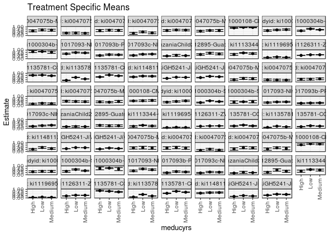

[figure not shown]

[figure not shown]

[figure not shown]

## Results Table

### Parameter: TSM

| agecat | studyid | country | intervention_level | baseline_level | estimate | ci_lower | ci_upper |
| --- | --- | --- | --- | --- | --- | --- | --- |
| 0-24 months | ki0047075b-MAL-ED | BANGLADESH | High | NA | 0.5384615 | 0.4275698 | 0.6493533 |
| 0-24 months | ki0047075b-MAL-ED | BANGLADESH | Low | NA | 0.6428571 | 0.5303463 | 0.7553680 |
| 0-24 months | ki0047075b-MAL-ED | BANGLADESH | Medium | NA | 0.6212121 | 0.5039086 | 0.7385157 |
| 0-24 months | ki0047075b-MAL-ED | BRAZIL | High | NA | 0.2784810 | 0.1794219 | 0.3775401 |
| 0-24 months | ki0047075b-MAL-ED | BRAZIL | Low | NA | 0.2857143 | 0.1739205 | 0.3975081 |
| 0-24 months | ki0047075b-MAL-ED | BRAZIL | Medium | NA | 0.2555556 | 0.1652481 | 0.3458630 |
| 0-24 months | ki0047075b-MAL-ED | INDIA | High | NA | 0.5714286 | 0.4489501 | 0.6939070 |
| 0-24 months | ki0047075b-MAL-ED | INDIA | Low | NA | 0.6184211 | 0.5089587 | 0.7278834 |
| 0-24 months | ki0047075b-MAL-ED | INDIA | Medium | NA | 0.5925926 | 0.4853450 | 0.6998402 |
| 0-24 months | ki0047075b-MAL-ED | NEPAL | High | NA | 0.2452830 | 0.1291908 | 0.3613753 |
| 0-24 months | ki0047075b-MAL-ED | NEPAL | Low | NA | 0.4166667 | 0.3178267 | 0.5155066 |
| 0-24 months | ki0047075b-MAL-ED | NEPAL | Medium | NA | 0.3026316 | 0.1991181 | 0.4061450 |
| 0-24 months | ki0047075b-MAL-ED | PERU | High | NA | 0.5824176 | 0.4809246 | 0.6839106 |
| 0-24 months | ki0047075b-MAL-ED | PERU | Low | NA | 0.6442308 | 0.5520678 | 0.7363938 |
| 0-24 months | ki0047075b-MAL-ED | PERU | Medium | NA | 0.6261682 | 0.5343434 | 0.7179930 |
| 0-24 months | ki0047075b-MAL-ED | SOUTH AFRICA | High | NA | 0.5052632 | 0.4045642 | 0.6059621 |
| 0-24 months | ki0047075b-MAL-ED | SOUTH AFRICA | Low | NA | 0.5866667 | 0.5077369 | 0.6655965 |
| 0-24 months | ki0047075b-MAL-ED | SOUTH AFRICA | Medium | NA | 0.5797101 | 0.4630571 | 0.6963632 |
| 0-24 months | ki1000108-CMC-V-BCS-2002 | INDIA | High | NA | 0.8924051 | 0.8440236 | 0.9407866 |
| 0-24 months | ki1000108-CMC-V-BCS-2002 | INDIA | Low | NA | 0.9528302 | 0.9124175 | 0.9932429 |
| 0-24 months | ki1000108-CMC-V-BCS-2002 | INDIA | Medium | NA | 0.9449541 | 0.9020810 | 0.9878273 |
| 0-24 months | ki1000108-IRC | INDIA | High | NA | 0.5725806 | 0.4854014 | 0.6597599 |
| 0-24 months | ki1000108-IRC | INDIA | Low | NA | 0.6530612 | 0.5760200 | 0.7301024 |
| 0-24 months | ki1000108-IRC | INDIA | Medium | NA | 0.6906475 | 0.6137121 | 0.7675828 |
| 0-24 months | ki1000304b-SAS-CompFeed | INDIA | High | NA | 0.5510836 | 0.4766961 | 0.6254711 |
| 0-24 months | ki1000304b-SAS-CompFeed | INDIA | Low | NA | 0.7729885 | 0.7210155 | 0.8249615 |
| 0-24 months | ki1000304b-SAS-CompFeed | INDIA | Medium | NA | 0.6692607 | 0.6396161 | 0.6989053 |
| 0-24 months | ki1000304b-SAS-FoodSuppl | INDIA | High | NA | 0.8292683 | 0.7139546 | 0.9445820 |
| 0-24 months | ki1000304b-SAS-FoodSuppl | INDIA | Low | NA | 0.8373494 | 0.7976046 | 0.8770942 |
| 0-24 months | ki1000304b-SAS-FoodSuppl | INDIA | Medium | NA | 0.7555556 | 0.6298411 | 0.8812700 |

[output cut: 183 more lines]

### Parameter: E(Y)

| agecat | studyid | country | intervention_level | baseline_level | estimate | ci_lower | ci_upper |
| --- | --- | --- | --- | --- | --- | --- | --- |
| 0-24 months | ki0047075b-MAL-ED | BANGLADESH | NA | NA | 0.5981308 | 0.5322895 | 0.6639722 |
| 0-24 months | ki0047075b-MAL-ED | BRAZIL | NA | NA | 0.2715517 | 0.2141972 | 0.3289063 |
| 0-24 months | ki0047075b-MAL-ED | INDIA | NA | NA | 0.5954545 | 0.5304515 | 0.6604576 |
| 0-24 months | ki0047075b-MAL-ED | NEPAL | NA | NA | 0.3377778 | 0.2758420 | 0.3997135 |
| 0-24 months | ki0047075b-MAL-ED | PERU | NA | NA | 0.6192053 | 0.5643489 | 0.6740617 |
| 0-24 months | ki0047075b-MAL-ED | SOUTH AFRICA | NA | NA | 0.5605096 | 0.5055248 | 0.6154943 |
| 0-24 months | ki1000108-CMC-V-BCS-2002 | INDIA | NA | NA | 0.9249330 | 0.8981563 | 0.9517096 |
| 0-24 months | ki1000108-IRC | INDIA | NA | NA | 0.6414634 | 0.5949863 | 0.6879405 |
| 0-24 months | ki1000304b-SAS-CompFeed | INDIA | NA | NA | 0.6914547 | 0.6510509 | 0.7318584 |
| 0-24 months | ki1000304b-SAS-FoodSuppl | INDIA | NA | NA | 0.8277512 | 0.7915095 | 0.8639929 |
| 0-24 months | ki1017093-NIH-Birth | BANGLADESH | NA | NA | 0.6645469 | 0.6276196 | 0.7014742 |
| 0-24 months | ki1017093b-PROVIDE | BANGLADESH | NA | NA | 0.4357143 | 0.3989556 | 0.4724730 |
| 0-24 months | ki1017093c-NIH-Crypto | BANGLADESH | NA | NA | 0.4775726 | 0.4419904 | 0.5131548 |
| 0-24 months | ki1066203-TanzaniaChild2 | TANZANIA, UNITED REPUBLIC OF | NA | NA | 0.3466052 | 0.3275063 | 0.3657041 |
| 0-24 months | ki1112895-Guatemala BSC | GUATEMALA | NA | NA | 0.5531915 | 0.4950624 | 0.6113206 |
| 0-24 months | ki1113344-GMS-Nepal | NEPAL | NA | NA | 0.6388489 | 0.6031124 | 0.6745854 |
| 0-24 months | ki1119695-PROBIT | BELARUS | NA | NA | 0.1674854 | 0.1488048 | 0.1861659 |
| 0-24 months | ki1126311-ZVITAMBO | ZIMBABWE | NA | NA | 0.4173189 | 0.4091660 | 0.4254718 |
| 0-24 months | ki1135781-COHORTS | GUATEMALA | NA | NA | 0.7658464 | 0.7431730 | 0.7885198 |
| 0-24 months | ki1135781-COHORTS | INDIA | NA | NA | 0.3817498 | 0.3693017 | 0.3941980 |
| 0-24 months | ki1135781-COHORTS | PHILIPPINES | NA | NA | 0.6863963 | 0.6699497 | 0.7028430 |
| 0-24 months | ki1148112-LCNI-5 | MALAWI | NA | NA | 0.6375921 | 0.6045496 | 0.6706347 |
| 0-24 months | kiGH5241-JiVitA-3 | BANGLADESH | NA | NA | 0.4953113 | 0.4874769 | 0.5031456 |
| 0-24 months | kiGH5241-JiVitA-4 | BANGLADESH | NA | NA | 0.5822107 | 0.5661650 | 0.5982565 |
| 0-6 months | ki0047075b-MAL-ED | BANGLADESH | NA | NA | 0.3411215 | 0.2774543 | 0.4047887 |
| 0-6 months | ki0047075b-MAL-ED | BRAZIL | NA | NA | 0.2241379 | 0.1703615 | 0.2779144 |
| 0-6 months | ki0047075b-MAL-ED | INDIA | NA | NA | 0.3272727 | 0.2651285 | 0.3894169 |
| 0-6 months | ki0047075b-MAL-ED | NEPAL | NA | NA | 0.1777778 | 0.1277101 | 0.2278455 |
| 0-6 months | ki0047075b-MAL-ED | PERU | NA | NA | 0.4238411 | 0.3680149 | 0.4796672 |
| 0-6 months | ki0047075b-MAL-ED | SOUTH AFRICA | NA | NA | 0.3694268 | 0.3159570 | 0.4228965 |
| 0-6 months | ki1000108-CMC-V-BCS-2002 | INDIA | NA | NA | 0.5108696 | 0.4597270 | 0.5620121 |
| 0-6 months | ki1000108-IRC | INDIA | NA | NA | 0.4243902 | 0.3764905 | 0.4722900 |
| 0-6 months | ki1000304b-SAS-CompFeed | INDIA | NA | NA | 0.4254902 | 0.3977202 | 0.4532601 |
| 0-6 months | ki1000304b-SAS-FoodSuppl | INDIA | NA | NA | 0.3894231 | 0.3425088 | 0.4363374 |
| 0-6 months | ki1017093-NIH-Birth | BANGLADESH | NA | NA | 0.3497615 | 0.3124631 | 0.3870600 |
| 0-6 months | ki1017093b-PROVIDE | BANGLADESH | NA | NA | 0.2400000 | 0.2083392 | 0.2716608 |
| 0-6 months | ki1017093c-NIH-Crypto | BANGLADESH | NA | NA | 0.3021108 | 0.2694011 | 0.3348205 |
| 0-6 months | ki1066203-TanzaniaChild2 | TANZANIA, UNITED REPUBLIC OF | NA | NA | 0.1948868 | 0.1789895 | 0.2107841 |
| 0-6 months | ki1112895-Guatemala BSC | GUATEMALA | NA | NA | 0.3169811 | 0.2608532 | 0.3731091 |
| 0-6 months | ki1113344-GMS-Nepal | NEPAL | NA | NA | 0.3194245 | 0.2847356 | 0.3541134 |
| 0-6 months | ki1119695-PROBIT | BELARUS | NA | NA | 0.0995087 | 0.0864641 | 0.1125533 |
| 0-6 months | ki1126311-ZVITAMBO | ZIMBABWE | NA | NA | 0.2587447 | 0.2514996 | 0.2659899 |
| 0-6 months | ki1135781-COHORTS | GUATEMALA | NA | NA | 0.3218924 | 0.2939898 | 0.3497950 |
| 0-6 months | ki1135781-COHORTS | INDIA | NA | NA | 0.1884493 | 0.1782621 | 0.1986366 |
| 0-6 months | ki1135781-COHORTS | PHILIPPINES | NA | NA | 0.2390451 | 0.2239262 | 0.2541640 |
| 0-6 months | ki1148112-LCNI-5 | MALAWI | NA | NA | 0.3558052 | 0.2982716 | 0.4133389 |
| 0-6 months | kiGH5241-JiVitA-3 | BANGLADESH | NA | NA | 0.4130202 | 0.4055695 | 0.4204710 |
| 0-6 months | kiGH5241-JiVitA-4 | BANGLADESH | NA | NA | 0.3474858 | 0.3322499 | 0.3627218 |
| 6-24 months | ki0047075b-MAL-ED | BANGLADESH | NA | NA | 0.4230769 | 0.3378215 | 0.5083323 |
| 6-24 months | ki0047075b-MAL-ED | INDIA | NA | NA | 0.4214286 | 0.3393403 | 0.5035169 |
| 6-24 months | ki0047075b-MAL-ED | NEPAL | NA | NA | 0.1978022 | 0.1397705 | 0.2558339 |
| 6-24 months | ki0047075b-MAL-ED | PERU | NA | NA | 0.3959732 | 0.3171819 | 0.4747644 |
| 6-24 months | ki0047075b-MAL-ED | SOUTH AFRICA | NA | NA | 0.3797468 | 0.3038314 | 0.4556622 |
| 6-24 months | ki1000108-CMC-V-BCS-2002 | INDIA | NA | NA | 0.8486486 | 0.7968646 | 0.9004327 |
| 6-24 months | ki1000108-IRC | INDIA | NA | NA | 0.3771186 | 0.3151523 | 0.4390850 |
| 6-24 months | ki1000304b-SAS-CompFeed | INDIA | NA | NA | 0.5030750 | 0.4588491 | 0.5473009 |
| 6-24 months | ki1000304b-SAS-FoodSuppl | INDIA | NA | NA | 0.7572016 | 0.7031798 | 0.8112234 |
| 6-24 months | ki1017093-NIH-Birth | BANGLADESH | NA | NA | 0.5739130 | 0.5216565 | 0.6261696 |
| 6-24 months | ki1017093b-PROVIDE | BANGLADESH | NA | NA | 0.3004386 | 0.2583143 | 0.3425629 |
| 6-24 months | ki1017093c-NIH-Crypto | BANGLADESH | NA | NA | 0.2628458 | 0.2244546 | 0.3012371 |
| 6-24 months | ki1066203-TanzaniaChild2 | TANZANIA, UNITED REPUBLIC OF | NA | NA | 0.2266750 | 0.2061344 | 0.2472157 |
| 6-24 months | ki1112895-Guatemala BSC | GUATEMALA | NA | NA | 0.3891892 | 0.3187405 | 0.4596379 |
| 6-24 months | ki1113344-GMS-Nepal | NEPAL | NA | NA | 0.5634518 | 0.5144179 | 0.6124857 |
| 6-24 months | ki1119695-PROBIT | BELARUS | NA | NA | 0.0768510 | 0.0628857 | 0.0908164 |
| 6-24 months | ki1126311-ZVITAMBO | ZIMBABWE | NA | NA | 0.2632323 | 0.2538603 | 0.2726044 |
| 6-24 months | ki1135781-COHORTS | GUATEMALA | NA | NA | 0.7666291 | 0.7387777 | 0.7944805 |
| 6-24 months | ki1135781-COHORTS | INDIA | NA | NA | 0.2595063 | 0.2466928 | 0.2723199 |
| 6-24 months | ki1135781-COHORTS | PHILIPPINES | NA | NA | 0.6449788 | 0.6246093 | 0.6653483 |
| 6-24 months | ki1148112-LCNI-5 | MALAWI | NA | NA | 0.5988701 | 0.5627418 | 0.6349983 |
| 6-24 months | kiGH5241-JiVitA-3 | BANGLADESH | NA | NA | 0.2160435 | 0.2066720 | 0.2254150 |
| 6-24 months | kiGH5241-JiVitA-4 | BANGLADESH | NA | NA | 0.3789503 | 0.3603576 | 0.3975429 |

### Parameter: RR

| agecat | studyid | country | intervention_level | baseline_level | estimate | ci_lower | ci_upper |
| --- | --- | --- | --- | --- | --- | --- | --- |
| 0-24 months | ki0047075b-MAL-ED | BANGLADESH | High | High | 1.0000000 | 1.0000000 | 1.0000000 |
| 0-24 months | ki0047075b-MAL-ED | BANGLADESH | Low | High | 1.1938776 | 0.9111406 | 1.5643509 |
| 0-24 months | ki0047075b-MAL-ED | BANGLADESH | Medium | High | 1.1536797 | 0.8724487 | 1.5255646 |
| 0-24 months | ki0047075b-MAL-ED | BRAZIL | High | High | 1.0000000 | 1.0000000 | 1.0000000 |
| 0-24 months | ki0047075b-MAL-ED | BRAZIL | Low | High | 1.0259740 | 0.6046183 | 1.7409707 |
| 0-24 months | ki0047075b-MAL-ED | BRAZIL | Medium | High | 0.9176768 | 0.5558179 | 1.5151196 |
| 0-24 months | ki0047075b-MAL-ED | INDIA | High | High | 1.0000000 | 1.0000000 | 1.0000000 |
| 0-24 months | ki0047075b-MAL-ED | INDIA | Low | High | 1.0822368 | 0.8195944 | 1.4290442 |
| 0-24 months | ki0047075b-MAL-ED | INDIA | Medium | High | 1.0370370 | 0.7833643 | 1.3728553 |
| 0-24 months | ki0047075b-MAL-ED | NEPAL | High | High | 1.0000000 | 1.0000000 | 1.0000000 |
| 0-24 months | ki0047075b-MAL-ED | NEPAL | Low | High | 1.6987179 | 1.0004559 | 2.8843277 |
| 0-24 months | ki0047075b-MAL-ED | NEPAL | Medium | High | 1.2338057 | 0.6880772 | 2.2123627 |
| 0-24 months | ki0047075b-MAL-ED | PERU | High | High | 1.0000000 | 1.0000000 | 1.0000000 |
| 0-24 months | ki0047075b-MAL-ED | PERU | Low | High | 1.1061321 | 0.8828568 | 1.3858739 |
| 0-24 months | ki0047075b-MAL-ED | PERU | Medium | High | 1.0751190 | 0.8561387 | 1.3501094 |
| 0-24 months | ki0047075b-MAL-ED | SOUTH AFRICA | High | High | 1.0000000 | 1.0000000 | 1.0000000 |
| 0-24 months | ki0047075b-MAL-ED | SOUTH AFRICA | Low | High | 1.1611111 | 0.9129417 | 1.4767417 |
| 0-24 months | ki0047075b-MAL-ED | SOUTH AFRICA | Medium | High | 1.1473430 | 0.8643570 | 1.5229772 |
| 0-24 months | ki1000108-CMC-V-BCS-2002 | INDIA | High | High | 1.0000000 | 1.0000000 | 1.0000000 |
| 0-24 months | ki1000108-CMC-V-BCS-2002 | INDIA | Low | High | 1.0677104 | 0.9966880 | 1.1437938 |
| 0-24 months | ki1000108-CMC-V-BCS-2002 | INDIA | Medium | High | 1.0588848 | 0.9866120 | 1.1364517 |
| 0-24 months | ki1000108-IRC | INDIA | High | High | 1.0000000 | 1.0000000 | 1.0000000 |
| 0-24 months | ki1000108-IRC | INDIA | Low | High | 1.1405576 | 0.9407354 | 1.3828242 |
| 0-24 months | ki1000108-IRC | INDIA | Medium | High | 1.2062012 | 0.9988205 | 1.4566396 |
| 0-24 months | ki1000304b-SAS-CompFeed | INDIA | High | High | 1.0000000 | 1.0000000 | 1.0000000 |
| 0-24 months | ki1000304b-SAS-CompFeed | INDIA | Low | High | 1.4026702 | 1.2030940 | 1.6353531 |
| 0-24 months | ki1000304b-SAS-CompFeed | INDIA | Medium | High | 1.2144450 | 1.0593825 | 1.3922040 |
| 0-24 months | ki1000304b-SAS-FoodSuppl | INDIA | High | High | 1.0000000 | 1.0000000 | 1.0000000 |
| 0-24 months | ki1000304b-SAS-FoodSuppl | INDIA | Low | High | 1.0097449 | 0.8717655 | 1.1695630 |
| 0-24 months | ki1000304b-SAS-FoodSuppl | INDIA | Medium | High | 0.9111111 | 0.7334960 | 1.1317356 |

[output cut: 183 more lines]

### Parameter: PAR

| agecat | studyid | country | intervention_level | baseline_level | estimate | ci_lower | ci_upper |
| --- | --- | --- | --- | --- | --- | --- | --- |
| 0-24 months | ki0047075b-MAL-ED | BANGLADESH | High | NA | 0.0596693 | -0.0278973 | 0.1472359 |
| 0-24 months | ki0047075b-MAL-ED | BRAZIL | High | NA | -0.0069293 | -0.0870508 | 0.0731922 |
| 0-24 months | ki0047075b-MAL-ED | INDIA | High | NA | 0.0240260 | -0.0790997 | 0.1271517 |
| 0-24 months | ki0047075b-MAL-ED | NEPAL | High | NA | 0.0924948 | -0.0122148 | 0.1972043 |
| 0-24 months | ki0047075b-MAL-ED | PERU | High | NA | 0.0367877 | -0.0474873 | 0.1210627 |
| 0-24 months | ki0047075b-MAL-ED | SOUTH AFRICA | High | NA | 0.0552464 | -0.0285853 | 0.1390781 |
| 0-24 months | ki1000108-CMC-V-BCS-2002 | INDIA | High | NA | 0.0325279 | -0.0002546 | 0.0653104 |
| 0-24 months | ki1000108-IRC | INDIA | High | NA | 0.0688828 | -0.0029722 | 0.1407377 |
| 0-24 months | ki1000304b-SAS-CompFeed | INDIA | High | NA | 0.1403711 | 0.0753345 | 0.2054077 |
| 0-24 months | ki1000304b-SAS-FoodSuppl | INDIA | High | NA | -0.0015171 | -0.1110714 | 0.1080373 |
| 0-24 months | ki1017093-NIH-Birth | BANGLADESH | High | NA | 0.0891279 | 0.0289102 | 0.1493456 |
| 0-24 months | ki1017093b-PROVIDE | BANGLADESH | High | NA | 0.0612462 | 0.0101471 | 0.1123453 |
| 0-24 months | ki1017093c-NIH-Crypto | BANGLADESH | High | NA | 0.0956828 | 0.0462350 | 0.1451306 |
| 0-24 months | ki1066203-TanzaniaChild2 | TANZANIA, UNITED REPUBLIC OF | High | NA | 0.0325955 | 0.0009108 | 0.0642802 |
| 0-24 months | ki1112895-Guatemala BSC | GUATEMALA | High | NA | 0.0616661 | -0.0069701 | 0.1303022 |
| 0-24 months | ki1113344-GMS-Nepal | NEPAL | High | NA | 0.1447313 | 0.0456203 | 0.2438422 |
| 0-24 months | ki1119695-PROBIT | BELARUS | High | NA | 0.0319220 | 0.0202123 | 0.0436316 |
| 0-24 months | ki1126311-ZVITAMBO | ZIMBABWE | High | NA | 0.0336620 | 0.0261556 | 0.0411685 |
| 0-24 months | ki1135781-COHORTS | GUATEMALA | High | NA | -0.0060834 | -0.0494360 | 0.0372691 |
| 0-24 months | ki1135781-COHORTS | INDIA | High | NA | 0.1988999 | 0.1727717 | 0.2250281 |
| 0-24 months | ki1135781-COHORTS | PHILIPPINES | High | NA | 0.1083912 | 0.0870244 | 0.1297580 |
| 0-24 months | ki1148112-LCNI-5 | MALAWI | High | NA | 0.0570552 | 0.0130833 | 0.1010272 |
| 0-24 months | kiGH5241-JiVitA-3 | BANGLADESH | High | NA | 0.0850975 | 0.0761961 | 0.0939989 |
| 0-24 months | kiGH5241-JiVitA-4 | BANGLADESH | High | NA | 0.0798436 | 0.0595721 | 0.1001150 |
| 0-6 months | ki0047075b-MAL-ED | BANGLADESH | High | NA | 0.0847112 | 0.0034066 | 0.1660158 |
| 0-6 months | ki0047075b-MAL-ED | BRAZIL | High | NA | -0.0163684 | -0.0921132 | 0.0593764 |
| 0-6 months | ki0047075b-MAL-ED | INDIA | High | NA | 0.0256854 | -0.0711371 | 0.1225080 |
| 0-6 months | ki0047075b-MAL-ED | NEPAL | High | NA | 0.0457023 | -0.0374883 | 0.1288929 |
| 0-6 months | ki0047075b-MAL-ED | PERU | High | NA | -0.0267084 | -0.1120475 | 0.0586307 |
| 0-6 months | ki0047075b-MAL-ED | SOUTH AFRICA | High | NA | -0.0095206 | -0.0909402 | 0.0718990 |
| 0-6 months | ki1000108-CMC-V-BCS-2002 | INDIA | High | NA | 0.0204237 | -0.0388661 | 0.0797135 |
| 0-6 months | ki1000108-IRC | INDIA | High | NA | 0.0856806 | 0.0146677 | 0.1566934 |
| 0-6 months | ki1000304b-SAS-CompFeed | INDIA | High | NA | 0.1313725 | 0.0918465 | 0.1708986 |
| 0-6 months | ki1000304b-SAS-FoodSuppl | INDIA | High | NA | 0.0394231 | -0.1016094 | 0.1804556 |
| 0-6 months | ki1017093-NIH-Birth | BANGLADESH | High | NA | 0.0536721 | -0.0039589 | 0.1113031 |
| 0-6 months | ki1017093b-PROVIDE | BANGLADESH | High | NA | 0.0229787 | -0.0207977 | 0.0667551 |
| 0-6 months | ki1017093c-NIH-Crypto | BANGLADESH | High | NA | 0.0698274 | 0.0255485 | 0.1141062 |
| 0-6 months | ki1066203-TanzaniaChild2 | TANZANIA, UNITED REPUBLIC OF | High | NA | 0.0048707 | -0.0217639 | 0.0315053 |
| 0-6 months | ki1112895-Guatemala BSC | GUATEMALA | High | NA | -0.0223046 | -0.0882169 | 0.0436078 |
| 0-6 months | ki1113344-GMS-Nepal | NEPAL | High | NA | 0.0958950 | 0.0114133 | 0.1803768 |
| 0-6 months | ki1119695-PROBIT | BELARUS | High | NA | 0.0178185 | 0.0061678 | 0.0294693 |
| 0-6 months | ki1126311-ZVITAMBO | ZIMBABWE | High | NA | 0.0148167 | 0.0081414 | 0.0214920 |
| 0-6 months | ki1135781-COHORTS | GUATEMALA | High | NA | 0.0540353 | 0.0016343 | 0.1064362 |
| 0-6 months | ki1135781-COHORTS | INDIA | High | NA | 0.0861917 | 0.0650351 | 0.1073482 |
| 0-6 months | ki1135781-COHORTS | PHILIPPINES | High | NA | 0.0523444 | 0.0337864 | 0.0709024 |
| 0-6 months | ki1148112-LCNI-5 | MALAWI | High | NA | 0.1029317 | 0.0240221 | 0.1818412 |
| 0-6 months | kiGH5241-JiVitA-3 | BANGLADESH | High | NA | 0.0812804 | 0.0727623 | 0.0897984 |
| 0-6 months | kiGH5241-JiVitA-4 | BANGLADESH | High | NA | 0.0551696 | 0.0354231 | 0.0749160 |
| 6-24 months | ki0047075b-MAL-ED | BANGLADESH | High | NA | 0.0079826 | -0.0946939 | 0.1106590 |
| 6-24 months | ki0047075b-MAL-ED | INDIA | High | NA | 0.0166667 | -0.1082989 | 0.1416322 |
| 6-24 months | ki0047075b-MAL-ED | NEPAL | High | NA | 0.0644689 | -0.0270826 | 0.1560203 |
| 6-24 months | ki0047075b-MAL-ED | PERU | High | NA | 0.1032902 | -0.0191390 | 0.2257195 |
| 6-24 months | ki0047075b-MAL-ED | SOUTH AFRICA | High | NA | 0.1006771 | -0.0176690 | 0.2190231 |
| 6-24 months | ki1000108-CMC-V-BCS-2002 | INDIA | High | NA | 0.0585252 | -0.0020112 | 0.1190616 |
| 6-24 months | ki1000108-IRC | INDIA | High | NA | 0.0234601 | -0.0609243 | 0.1078445 |
| 6-24 months | ki1000304b-SAS-CompFeed | INDIA | High | NA | 0.1134037 | 0.0201789 | 0.2066285 |
| 6-24 months | ki1000304b-SAS-FoodSuppl | INDIA | High | NA | 0.0164609 | -0.1392877 | 0.1722095 |
| 6-24 months | ki1017093-NIH-Birth | BANGLADESH | High | NA | 0.1234626 | 0.0473447 | 0.1995805 |
| 6-24 months | ki1017093b-PROVIDE | BANGLADESH | High | NA | 0.0734447 | 0.0190759 | 0.1278136 |
| 6-24 months | ki1017093c-NIH-Crypto | BANGLADESH | High | NA | 0.0607182 | 0.0125291 | 0.1089073 |
| 6-24 months | ki1066203-TanzaniaChild2 | TANZANIA, UNITED REPUBLIC OF | High | NA | 0.0365516 | 0.0027567 | 0.0703464 |
| 6-24 months | ki1112895-Guatemala BSC | GUATEMALA | High | NA | 0.1189189 | 0.0351228 | 0.2027151 |
| 6-24 months | ki1113344-GMS-Nepal | NEPAL | High | NA | 0.1527375 | 0.0330814 | 0.2723936 |
| 6-24 months | ki1119695-PROBIT | BELARUS | High | NA | 0.0168510 | 0.0059223 | 0.0277798 |
| 6-24 months | ki1126311-ZVITAMBO | ZIMBABWE | High | NA | 0.0362594 | 0.0277564 | 0.0447623 |
| 6-24 months | ki1135781-COHORTS | GUATEMALA | High | NA | -0.0754762 | -0.1235806 | -0.0273717 |
| 6-24 months | ki1135781-COHORTS | INDIA | High | NA | 0.1587656 | 0.1358514 | 0.1816798 |
| 6-24 months | ki1135781-COHORTS | PHILIPPINES | High | NA | 0.1068780 | 0.0816980 | 0.1320579 |
| 6-24 months | ki1148112-LCNI-5 | MALAWI | High | NA | 0.0416745 | -0.0044387 | 0.0877877 |
| 6-24 months | kiGH5241-JiVitA-3 | BANGLADESH | High | NA | 0.0428322 | 0.0331350 | 0.0525294 |
| 6-24 months | kiGH5241-JiVitA-4 | BANGLADESH | High | NA | 0.0657674 | 0.0422140 | 0.0893209 |

### Parameter: PAF

| agecat | studyid | country | intervention_level | baseline_level | estimate | ci_lower | ci_upper |
| --- | --- | --- | --- | --- | --- | --- | --- |
| 0-24 months | ki0047075b-MAL-ED | BANGLADESH | High | NA | 0.0997596 | -0.0600297 | 0.2354622 |
| 0-24 months | ki0047075b-MAL-ED | BRAZIL | High | NA | -0.0255174 | -0.3673779 | 0.2308740 |
| 0-24 months | ki0047075b-MAL-ED | INDIA | High | NA | 0.0403490 | -0.1495734 | 0.1988940 |
| 0-24 months | ki0047075b-MAL-ED | NEPAL | High | NA | 0.2738332 | -0.1112253 | 0.5254623 |
| 0-24 months | ki0047075b-MAL-ED | PERU | High | NA | 0.0594112 | -0.0872722 | 0.1863055 |
| 0-24 months | ki0047075b-MAL-ED | SOUTH AFRICA | High | NA | 0.0985646 | -0.0646009 | 0.2367226 |
| 0-24 months | ki1000108-CMC-V-BCS-2002 | INDIA | High | NA | 0.0351679 | -0.0012783 | 0.0702874 |
| 0-24 months | ki1000108-IRC | INDIA | High | NA | 0.1073838 | -0.0126362 | 0.2131787 |
| 0-24 months | ki1000304b-SAS-CompFeed | INDIA | High | NA | 0.2030084 | 0.1031688 | 0.2917333 |
| 0-24 months | ki1000304b-SAS-FoodSuppl | INDIA | High | NA | -0.0018328 | -0.1433253 | 0.1221493 |
| 0-24 months | ki1017093-NIH-Birth | BANGLADESH | High | NA | 0.1341183 | 0.0377683 | 0.2208206 |
| 0-24 months | ki1017093b-PROVIDE | BANGLADESH | High | NA | 0.1405651 | 0.0146852 | 0.2503630 |
| 0-24 months | ki1017093c-NIH-Crypto | BANGLADESH | High | NA | 0.2003524 | 0.0892457 | 0.2979047 |
| 0-24 months | ki1066203-TanzaniaChild2 | TANZANIA, UNITED REPUBLIC OF | High | NA | 0.0940423 | -0.0021369 | 0.1809907 |
| 0-24 months | ki1112895-Guatemala BSC | GUATEMALA | High | NA | 0.1114733 | -0.0224414 | 0.2278484 |
| 0-24 months | ki1113344-GMS-Nepal | NEPAL | High | NA | 0.2265501 | 0.0536606 | 0.3678539 |
| 0-24 months | ki1119695-PROBIT | BELARUS | High | NA | 0.1905956 | 0.1219593 | 0.2538666 |
| 0-24 months | ki1126311-ZVITAMBO | ZIMBABWE | High | NA | 0.0806626 | 0.0624759 | 0.0984966 |
| 0-24 months | ki1135781-COHORTS | GUATEMALA | High | NA | -0.0079434 | -0.0661734 | 0.0471063 |
| 0-24 months | ki1135781-COHORTS | INDIA | High | NA | 0.5210216 | 0.4484458 | 0.5840475 |
| 0-24 months | ki1135781-COHORTS | PHILIPPINES | High | NA | 0.1579135 | 0.1255670 | 0.1890634 |
| 0-24 months | ki1148112-LCNI-5 | MALAWI | High | NA | 0.0894855 | 0.0174710 | 0.1562216 |
| 0-24 months | kiGH5241-JiVitA-3 | BANGLADESH | High | NA | 0.1718061 | 0.1534036 | 0.1898085 |
| 0-24 months | kiGH5241-JiVitA-4 | BANGLADESH | High | NA | 0.1371386 | 0.1010251 | 0.1718014 |
| 0-6 months | ki0047075b-MAL-ED | BANGLADESH | High | NA | 0.2483316 | -0.0307597 | 0.4518554 |
| 0-6 months | ki0047075b-MAL-ED | BRAZIL | High | NA | -0.0730282 | -0.4700008 | 0.2167422 |
| 0-6 months | ki0047075b-MAL-ED | INDIA | High | NA | 0.0784832 | -0.2703173 | 0.3315110 |
| 0-6 months | ki0047075b-MAL-ED | NEPAL | High | NA | 0.2570755 | -0.3875966 | 0.6022354 |
| 0-6 months | ki0047075b-MAL-ED | PERU | High | NA | -0.0630151 | -0.2848105 | 0.1204920 |
| 0-6 months | ki0047075b-MAL-ED | SOUTH AFRICA | High | NA | -0.0257713 | -0.2716411 | 0.1725599 |
| 0-6 months | ki1000108-CMC-V-BCS-2002 | INDIA | High | NA | 0.0399783 | -0.0834630 | 0.1493557 |
| 0-6 months | ki1000108-IRC | INDIA | High | NA | 0.2018910 | 0.0153899 | 0.3530658 |
| 0-6 months | ki1000304b-SAS-CompFeed | INDIA | High | NA | 0.3087558 | 0.2020735 | 0.4011746 |
| 0-6 months | ki1000304b-SAS-FoodSuppl | INDIA | High | NA | 0.1012346 | -0.3448068 | 0.3993343 |
| 0-6 months | ki1017093-NIH-Birth | BANGLADESH | High | NA | 0.1534535 | -0.0283593 | 0.3031221 |
| 0-6 months | ki1017093b-PROVIDE | BANGLADESH | High | NA | 0.0957447 | -0.1061260 | 0.2607735 |
| 0-6 months | ki1017093c-NIH-Crypto | BANGLADESH | High | NA | 0.2311316 | 0.0705318 | 0.3639819 |
| 0-6 months | ki1066203-TanzaniaChild2 | TANZANIA, UNITED REPUBLIC OF | High | NA | 0.0249926 | -0.1217070 | 0.1525066 |
| 0-6 months | ki1112895-Guatemala BSC | GUATEMALA | High | NA | -0.0703656 | -0.2998723 | 0.1186191 |
| 0-6 months | ki1113344-GMS-Nepal | NEPAL | High | NA | 0.3002120 | -0.0201814 | 0.5199841 |
| 0-6 months | ki1119695-PROBIT | BELARUS | High | NA | 0.1790651 | 0.0632816 | 0.2805371 |
| 0-6 months | ki1126311-ZVITAMBO | ZIMBABWE | High | NA | 0.0572637 | 0.0311262 | 0.0826962 |
| 0-6 months | ki1135781-COHORTS | GUATEMALA | High | NA | 0.1678674 | -0.0117714 | 0.3156116 |
| 0-6 months | ki1135781-COHORTS | INDIA | High | NA | 0.4573733 | 0.3351718 | 0.5571129 |
| 0-6 months | ki1135781-COHORTS | PHILIPPINES | High | NA | 0.2189727 | 0.1380468 | 0.2923008 |
| 0-6 months | ki1148112-LCNI-5 | MALAWI | High | NA | 0.2892922 | 0.0304643 | 0.4790232 |
| 0-6 months | kiGH5241-JiVitA-3 | BANGLADESH | High | NA | 0.1967952 | 0.1759004 | 0.2171601 |
| 0-6 months | kiGH5241-JiVitA-4 | BANGLADESH | High | NA | 0.1587678 | 0.0999603 | 0.2137329 |
| 6-24 months | ki0047075b-MAL-ED | BANGLADESH | High | NA | 0.0188679 | -0.2564898 | 0.2338815 |
| 6-24 months | ki0047075b-MAL-ED | INDIA | High | NA | 0.0395480 | -0.3079078 | 0.2946995 |
| 6-24 months | ki0047075b-MAL-ED | NEPAL | High | NA | 0.3259259 | -0.3262663 | 0.6574022 |
| 6-24 months | ki0047075b-MAL-ED | PERU | High | NA | 0.2608516 | -0.1228401 | 0.5134300 |
| 6-24 months | ki0047075b-MAL-ED | SOUTH AFRICA | High | NA | 0.2651163 | -0.1223401 | 0.5188142 |
| 6-24 months | ki1000108-CMC-V-BCS-2002 | INDIA | High | NA | 0.0689628 | -0.0064293 | 0.1387073 |
| 6-24 months | ki1000108-IRC | INDIA | High | NA | 0.0622088 | -0.1905435 | 0.2613019 |
| 6-24 months | ki1000304b-SAS-CompFeed | INDIA | High | NA | 0.2254210 | 0.0182143 | 0.3888965 |
| 6-24 months | ki1000304b-SAS-FoodSuppl | INDIA | High | NA | 0.0217391 | -0.2072103 | 0.2072679 |
| 6-24 months | ki1017093-NIH-Birth | BANGLADESH | High | NA | 0.2151242 | 0.0687306 | 0.3385050 |
| 6-24 months | ki1017093b-PROVIDE | BANGLADESH | High | NA | 0.2444584 | 0.0414337 | 0.4044824 |
| 6-24 months | ki1017093c-NIH-Crypto | BANGLADESH | High | NA | 0.2310030 | 0.0257520 | 0.3930125 |
| 6-24 months | ki1066203-TanzaniaChild2 | TANZANIA, UNITED REPUBLIC OF | High | NA | 0.1612509 | -0.0014751 | 0.2975362 |
| 6-24 months | ki1112895-Guatemala BSC | GUATEMALA | High | NA | 0.3055556 | 0.0542496 | 0.4900842 |
| 6-24 months | ki1113344-GMS-Nepal | NEPAL | High | NA | 0.2710746 | 0.0229984 | 0.4561604 |
| 6-24 months | ki1119695-PROBIT | BELARUS | High | NA | 0.2192689 | 0.0626778 | 0.3496996 |
| 6-24 months | ki1126311-ZVITAMBO | ZIMBABWE | High | NA | 0.1377466 | 0.1049804 | 0.1693133 |
| 6-24 months | ki1135781-COHORTS | GUATEMALA | High | NA | -0.0984520 | -0.1636947 | -0.0368672 |
| 6-24 months | ki1135781-COHORTS | INDIA | High | NA | 0.6117985 | 0.5174540 | 0.6876974 |
| 6-24 months | ki1135781-COHORTS | PHILIPPINES | High | NA | 0.1657077 | 0.1249996 | 0.2045219 |
| 6-24 months | ki1148112-LCNI-5 | MALAWI | High | NA | 0.0695885 | -0.0109086 | 0.1436758 |
| 6-24 months | kiGH5241-JiVitA-3 | BANGLADESH | High | NA | 0.1982574 | 0.1523980 | 0.2416356 |
| 6-24 months | kiGH5241-JiVitA-4 | BANGLADESH | High | NA | 0.1735517 | 0.1081554 | 0.2341526 |